# Exploratory Analysis of loan_data Loans By M Ramadan

## Initial Dataset Exploration

```
## [1] "D:/Data Anylst Track"
```

```
##  [1] "ListingKey"
##  [2] "ListingNumber"
##  [3] "ListingCreationDate"
##  [4] "CreditGrade"
##  [5] "Term"
##  [6] "LoanStatus"
##  [7] "ClosedDate"
##  [8] "BorrowerAPR"
##  [9] "BorrowerRate"
## [10] "LenderYield"
## [11] "EstimatedEffectiveYield"
## [12] "EstimatedLoss"
## [13] "EstimatedReturn"
## [14] "ProsperRating..numeric."
## [15] "ProsperRating..Alpha."
```

[output cut: 66 more lines]

```
## 'data.frame':    113937 obs. of  81 variables:
##  $ ListingKey                         : Factor w/ 113066 levels "00003546482094282EF90E5",..: 7180 7193 6647 6669 6686 6689 6699 6706 6687 6687 ...
##  $ ListingNumber                      : int  193129 1209647 81716 658116 909464 1074836 750899 768193 1023355 1023355 ...
##  $ ListingCreationDate                : Factor w/ 113064 levels "2005-11-09 20:44:28.847000000",..: 14184 111894 6429 64760 85967 100310 72556 74019 97834 97834 ...
##  $ CreditGrade                        : Factor w/ 9 levels "","A","AA","B",..: 5 1 8 1 1 1 1 1 1 1 ...
##  $ Term                               : int  36 36 36 36 36 60 36 36 36 36 ...
##  $ LoanStatus                         : Factor w/ 12 levels "Cancelled","Chargedoff",..: 3 4 3 4 4 4 4 4 4 4 ...
##  $ ClosedDate                         : Factor w/ 2803 levels "","2005-11-25 00:00:00",..: 1138 1 1263 1 1 1 1 1 1 1 ...
##  $ BorrowerAPR                        : num  0.165 0.12 0.283 0.125 0.246 ...
##  $ BorrowerRate                       : num  0.158 0.092 0.275 0.0974 0.2085 ...
##  $ LenderYield                        : num  0.138 0.082 0.24 0.0874 0.1985 ...
##  $ EstimatedEffectiveYield            : num  NA 0.0796 NA 0.0849 0.1832 ...
##  $ EstimatedLoss                      : num  NA 0.0249 NA 0.0249 0.0925 ...
##  $ EstimatedReturn                    : num  NA 0.0547 NA 0.06 0.0907 ...
##  $ ProsperRating..numeric.            : int  NA 6 NA 6 3 5 2 4 7 7 ...
```

[output cut: 67 more lines]

```
## [1] 113937
```

```
## [1] 81
```

[figure not shown]

```
##    AA     A     B     C     D     E    HR    NA  NA's
##  5372 14551 15581 18345 14274  9795  6935     0 29084
```

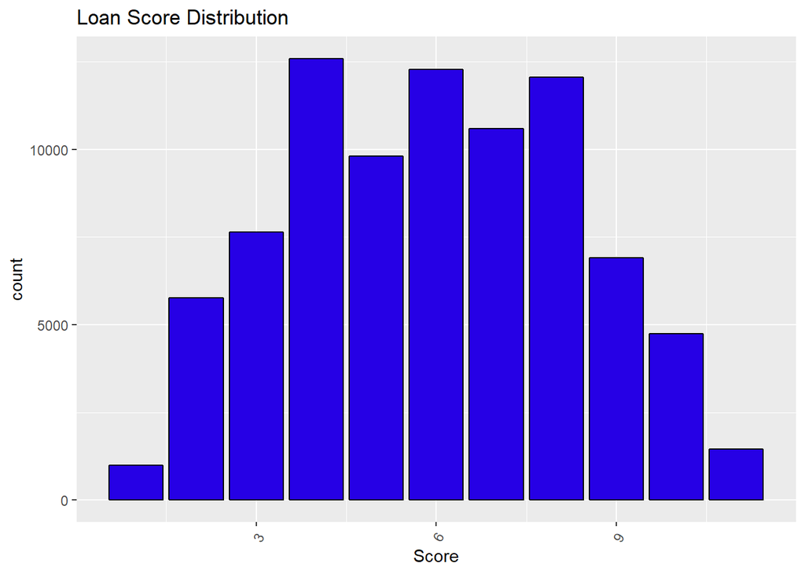

```
##    Min. 1st Qu.  Median    Mean 3rd Qu.    Max.    NA's
##    1.00    4.00    6.00    5.95    8.00   11.00   29084
```

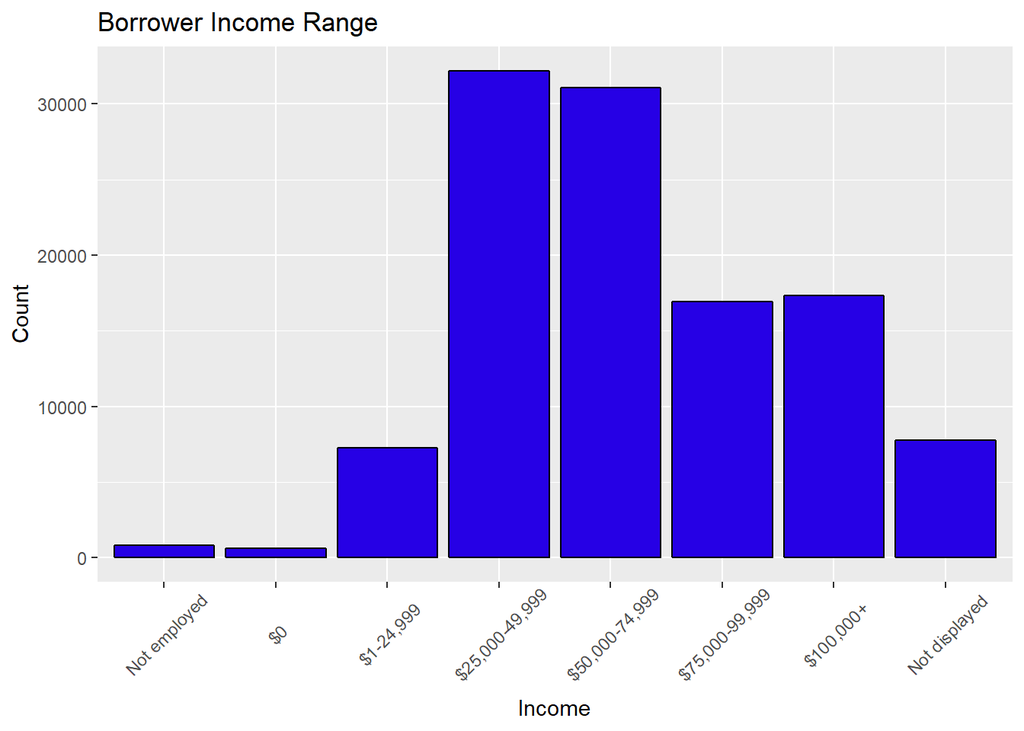

Here we can found that most of Prosper Loan’s customers income range is between $25,000-49,999

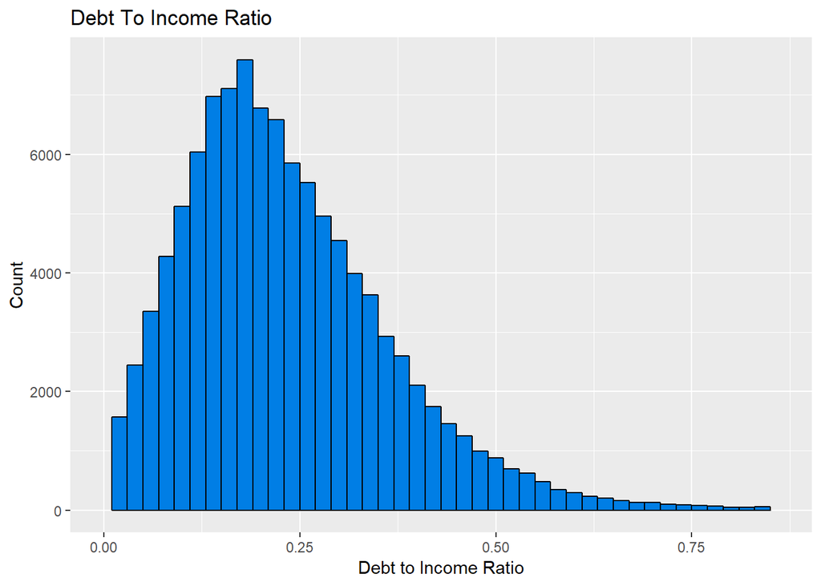

```
##    Min. 1st Qu.  Median    Mean 3rd Qu.    Max.    NA's
##   0.000   0.140   0.220   0.276   0.320  10.010    8554
```

The graph show long-tailed right-skewed. the majority of people have a credit history, and the ratio should be low enough for a secured repayment. 25% of the income is the threshold for most of the borrowers.

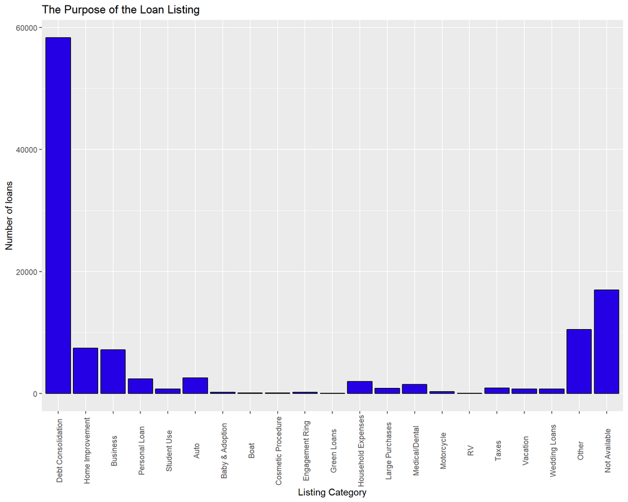

```
## Debt Consolidation   Home Improvement           Business
##              58308               7433               7189
##      Personal Loan        Student Use               Auto
##               2395                756               2572
##    Baby & Adoption               Boat Cosmetic Procedure
##                199                 85                 91
##    Engagement Ring        Green Loans Household Expenses
##                217                 59               1996
##    Large Purchases     Medical/Dental         Motorcycle
##                876               1522                304
##                 RV              Taxes           Vacation
##                 52                885                768
##      Wedding Loans              Other      Not Available
##                771              10494              16965
```

More than 50% of loan are for debt consolidation wich explain the data for income range ,but also we found many people hide the the purpose of loan.

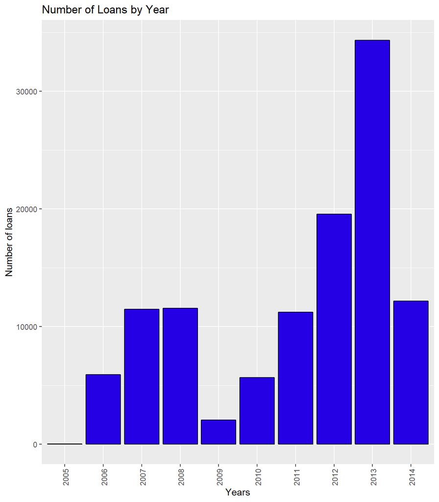

```
##    Min. 1st Qu.  Median    Mean 3rd Qu.    Max.
##    2005    2008    2012    2011    2013    2014
```

The chart took a plunge in 2009 and exploded the year after and peaked in 2013. Now, this period is coincide with the 2008 Global Financial Crisis and government must have conducted certain action toward credit-typed business.

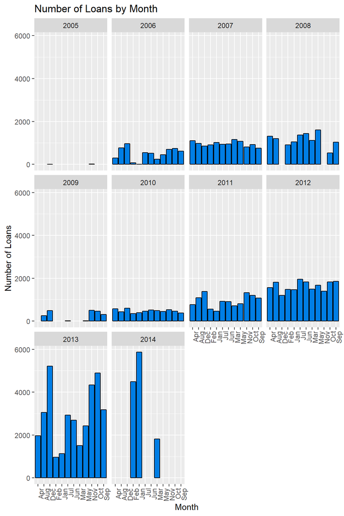

very low loan activities in 2009 and the extremely high growth in 2013. Probably in 2013, business went back to normal and the demand for credit increased.

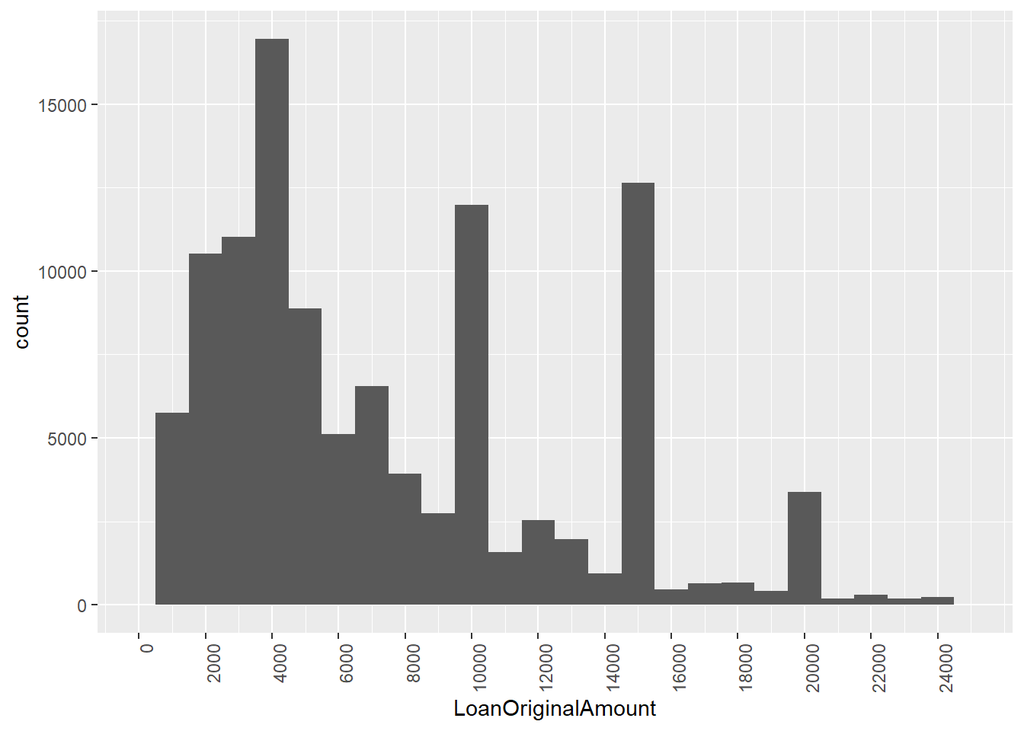

```
##    Min. 1st Qu.  Median    Mean 3rd Qu.    Max.
##    1000    4000    6500    8337   12000   35000
```

[figure not shown]

```
##                    Employed     Full-time Not available  Not employed
##          2255         67322         26355          5347           835
##         Other     Part-time       Retired Self-employed
##          3806          1088           795          6134
```

Among these criteria, probably people would tick in “Employed” box & would not fill-in other details, which also explained why self-employed borrowers are higher than part-time employment.

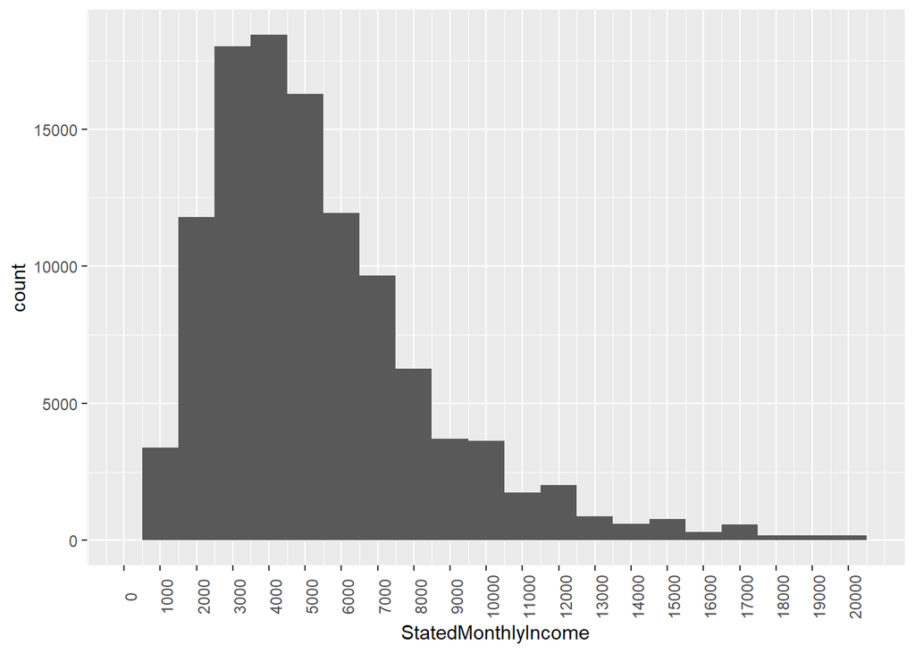

```
##    Min. 1st Qu.  Median    Mean 3rd Qu.    Max.
##       0    3200    4667    5608    6825 1750003
```

median income range is at $4667 and mean of $5608 which is quite average for a professional with few years of experience.

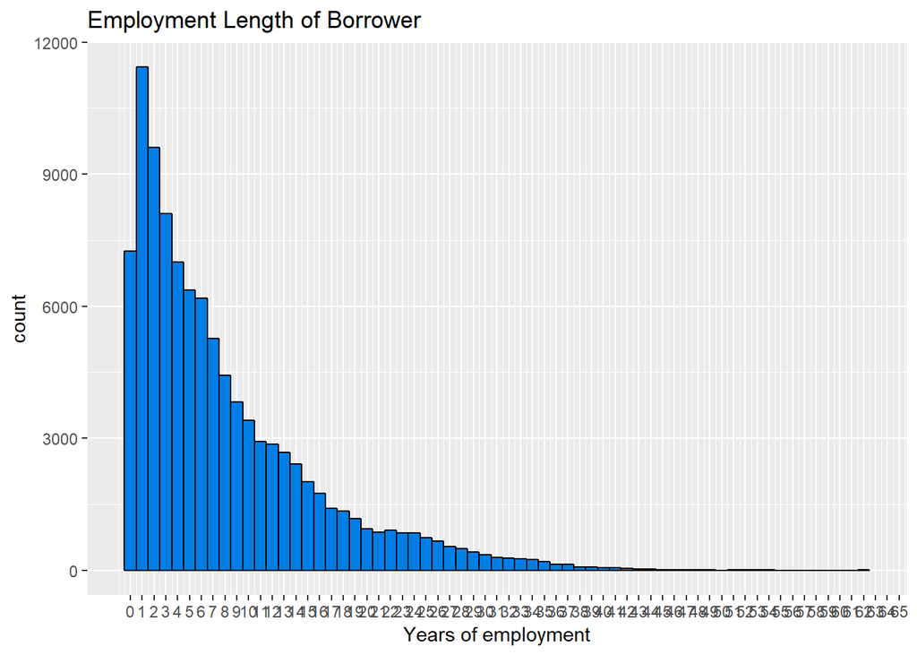

```
##    Min. 1st Qu.  Median    Mean 3rd Qu.    Max.    NA's
##   0.000   2.167   5.583   8.006  11.417  62.917    7625
```

As expected, I see the data is in favor of people have fewer years of employment and as they aging, they do not need much loan as before.

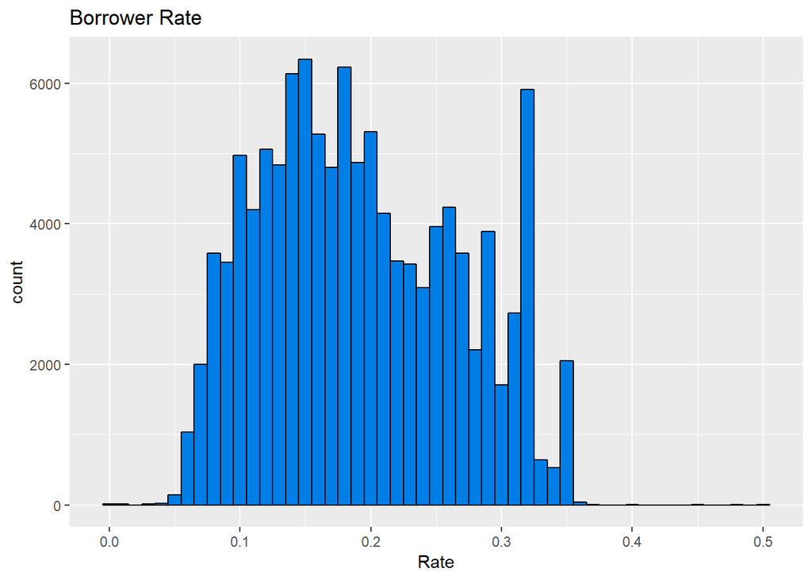

```
##    Min. 1st Qu.  Median    Mean 3rd Qu.    Max.
##  0.0000  0.1340  0.1840  0.1928  0.2500  0.4975
```

it’s interesting to know the median borrower rate. I’d suspect they have different borrower rate for different term & rating but here we get a median of 18.4%. However, there is a huge notable spike around 31%, which is a very attractive rate for the investors. This is something we can keep in mind while looking for further investigation.

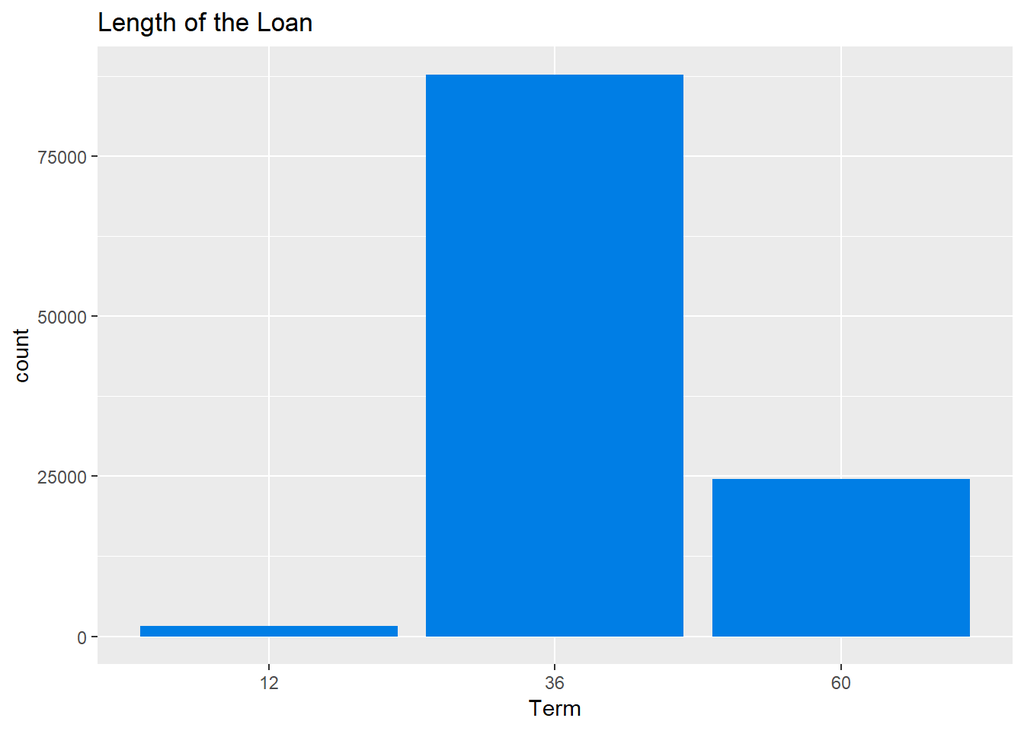

[output not shown]

This is an interesting piece of information we would want to investigate further. 36-month term loan is the most sought-after term, if we couple this with the previous common Borrower Rate, a 3 years loan with median 18.4% borrower rate is a very attractive rate for this business.

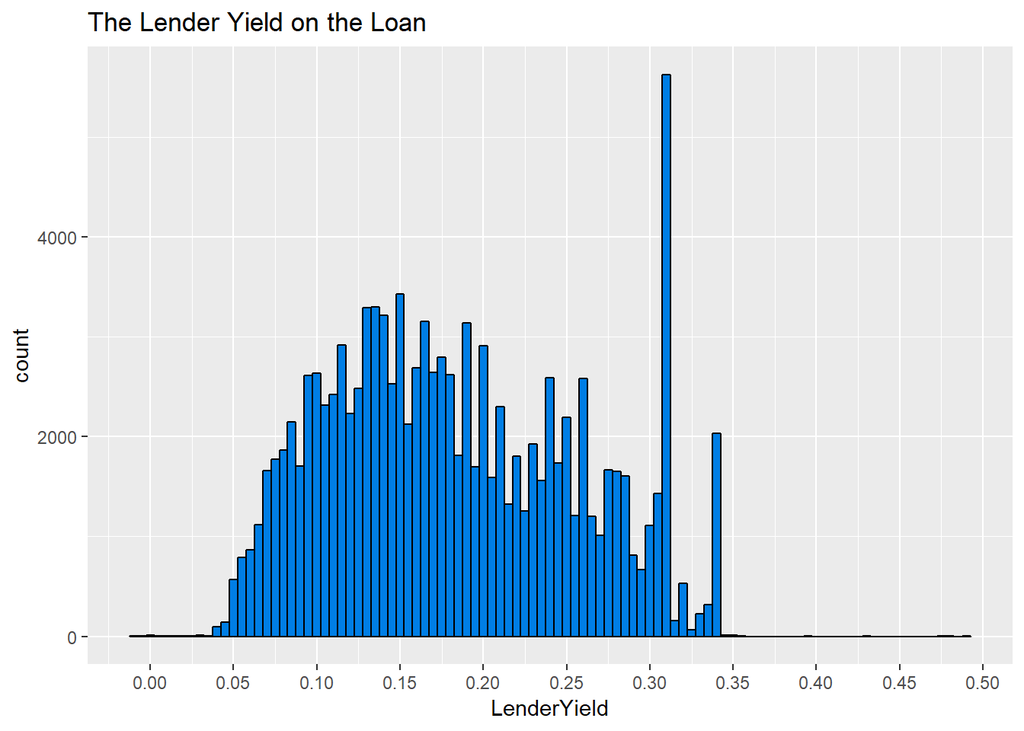

This chart is quite similar with the previous chat for borrower rate. As someone who’s completely new to the industry, I did not fully comprehend there’s a very linear and strong relationship between borrower rate and lender yield, which unfold later on during bivariate analysis.

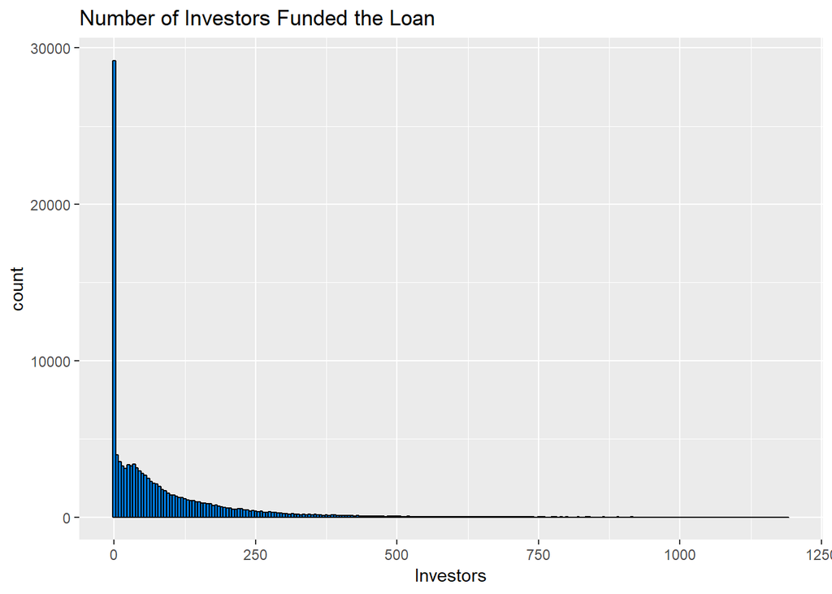

```
##
## FALSE  TRUE
## 86123 27814
```

Out of 113937 loans, about 24.4% are funded individually. This is a very high concentration toward 1 investor. However, if we keep in mind 75% of loan are below $12000. This would make sense.

# Univariate Analysis

#### What is/are the main feature(s) of interest in your dataset?

after divde the dataset into two main different aspects :

For Borrower, I believe the Prosper Score, Proser Rating (both numeric & alphabet) are the main indicators of a quality of borrowers. Further bivariate analysis would help to learn about these 2.

For Lender, I now understand Lender Yield is the most important factor for investor.

As a marketplace, Prosper would be more interest in Service Fees & Collection Fees but we would not dive into these variables in our analysis.

#### What other features in the dataset do you think will help support your investigation into your feature(s) of interest?

Also, I didn’t find nothing so interesting about risk score and income level, two variable that I was expecting more. On the other hand, maybe this variables have more to tell when related to others. I would like to understand better why loans with term of 36-months are more dispersed than 60 months. Also I want to find out why risky loans are classified that way.

#### Did you create any new variables from existing variables in the dataset?

yes also I factorizing a few variables .

#### Of the features you investigated, were there any unusual distributions? Did you perform any operations on the data to tidy, adjust, or change the form of the data? If so, why did you do this?

Yes, there is few unsual distribution, I was particularly pay attention to the high spike in lender yield & borrower rate and the spike in LoanOriginalAmount that people tend to buy in bulk. I was factorizing data and since categorical variables enter into statistical models differently than continuous variables, storing data as factors insures that the modeling functions will treat such data correctly.

# Bivariate Plots Section

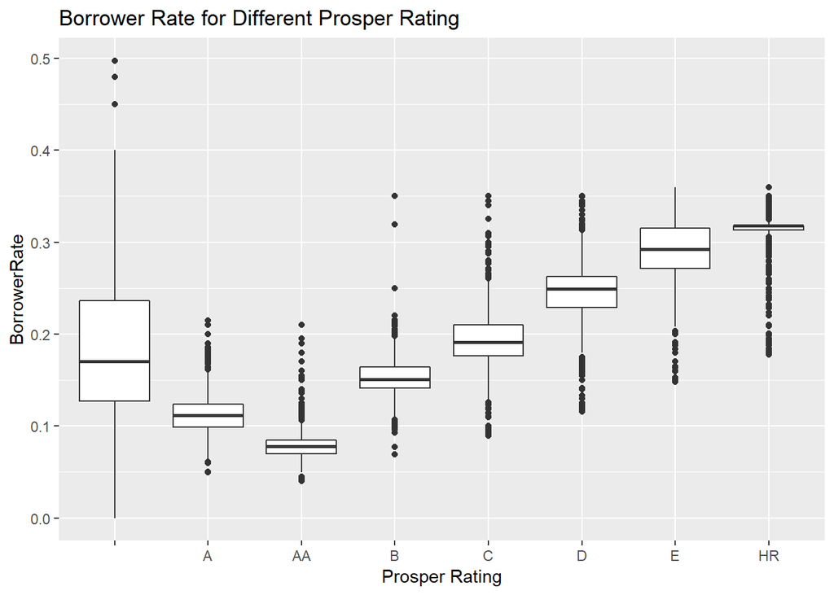

As we can see, with better rating and safe borrower, the borrower rate is having an inveser relationship with the prosper rating.

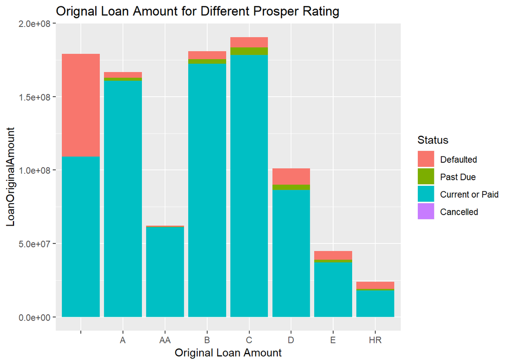

The lower the rank, the more loans get defaulted. The graph might be mistaken as E and HR have less defaulted loans than others, but also keeps in mind loans were less categorized into that area.

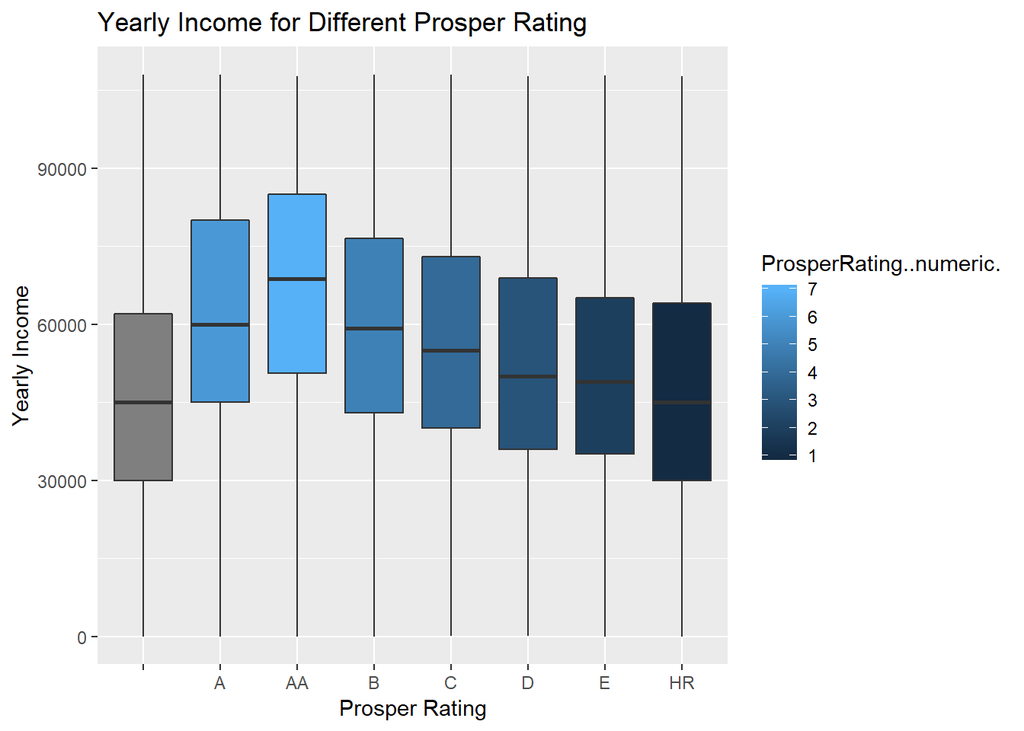

```
##     Min.  1st Qu.   Median     Mean  3rd Qu.     Max.
##        0    38404    56000    67296    81900 21000035
```

For this graph, we explicitly excluded MonthlyIncome more than 9000 and no income as there’re few outliers have monthly income more than 9000 and the chart cannot displayed properly.

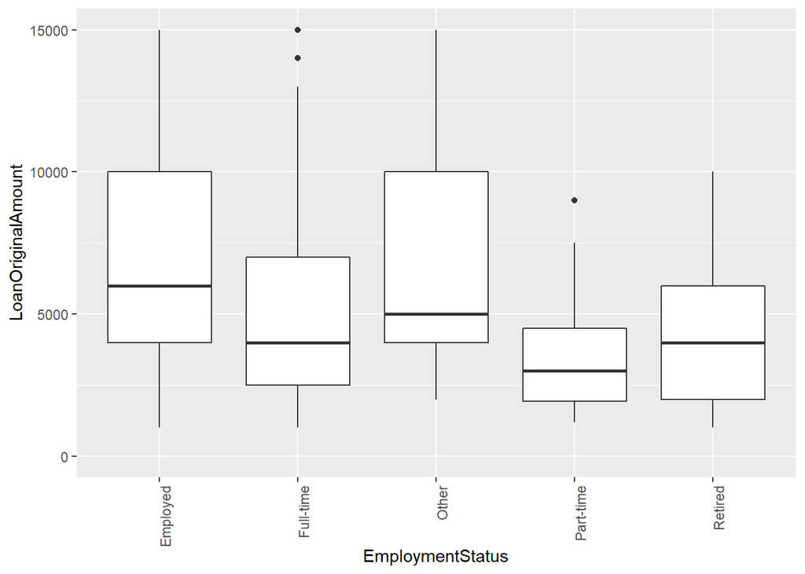

Retired category seems to have higher loan original amount than part-time. This part of data is quite interesting but I don’t really know why such event would happen.

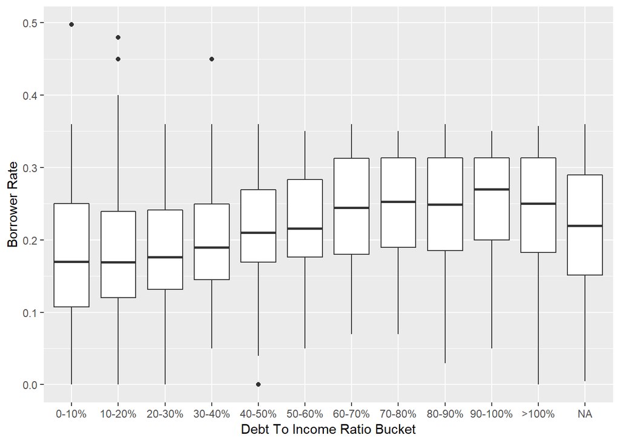

```
## [1] 0.06291678
```

As much as I want to believe, although there is some sort of relationship between Debt To Income ratio & Borrower Rate, the relationship is not that significant when we do a correlation test. I also did a few back-of-the-envelope graph and shows no significant relationship between BorrowerRate & other factors.

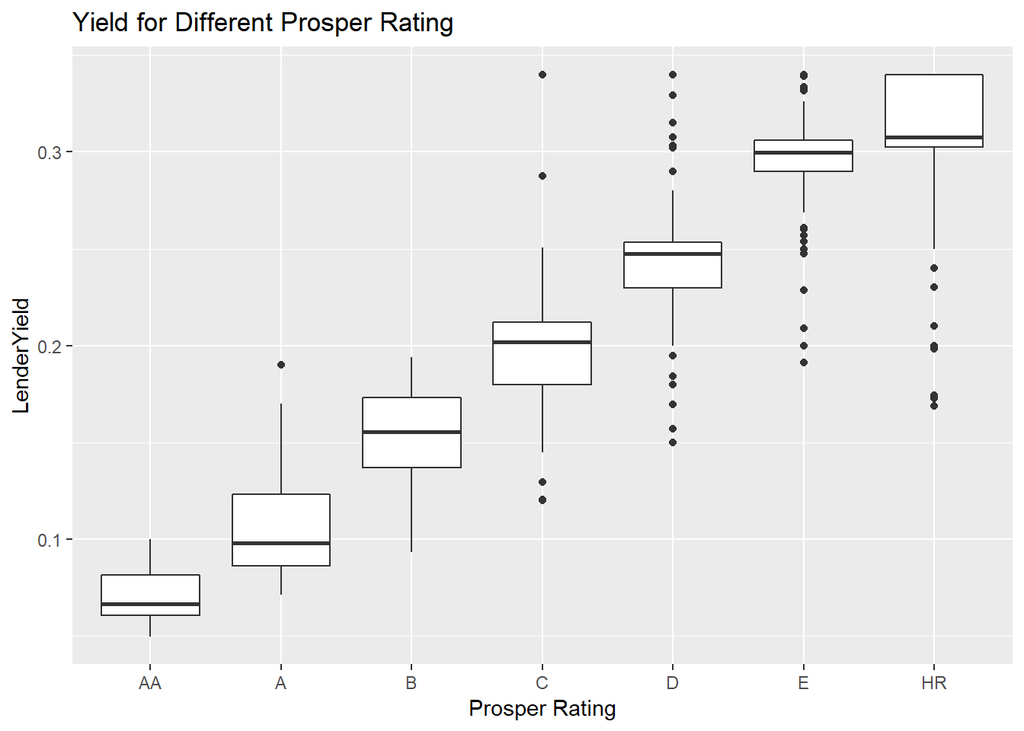

Similar graph with Borrower Rate, nothing worth notice here.

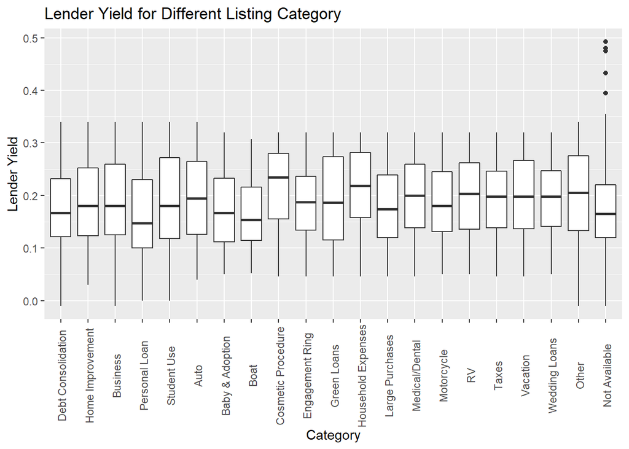

I initially thought there must be better yield for riskier category but it seems like there’s no relationship here.

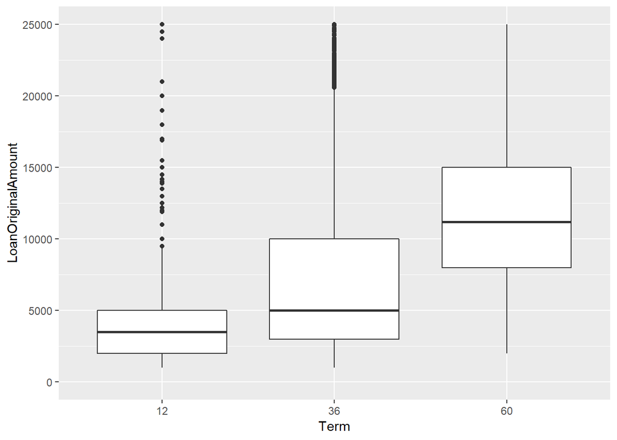

This chart is a new interesting insight, although the majority of loan are in 36-month term. The Loan original amount is significantly higher for 60 months term. Let’s see if it’s hold true for Lender Yield

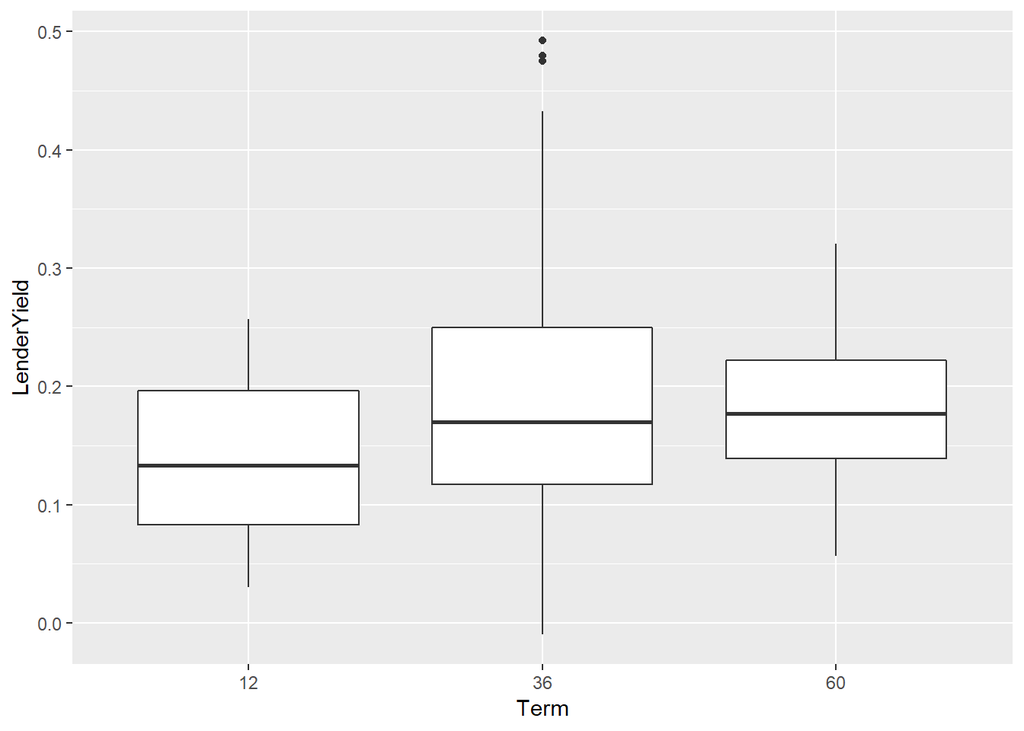

Unfortunately, this is not the case. Term Loan have higher Loan Original Amount because it’d need more time to repay those loans.

# Bivariate Analysis

#### Talk about some of the relationships you observed in this part of the investigation. How did the feature(s) of interest vary with other features in the dataset?

I want to explore 2 main variables Lender Yield and Borrower Rate and see which other related variables have the most effect on it. So far, the only relationship I found is through the proprietory Prosper Scoring system. Other factor I was trying to compare was not having any particular relationship. #### Did you observe any interesting relationships between the other features (not the main feature(s) of interest)? No #### What was the strongest relationship you found? The relationship between (Prosper Rating and Lender Yield) and (Prosper Rating and Borrower Rate) has an inversed relationship. The higher the rating, the lower the borrower rate and lender yield.

# Multivariate Plots Section

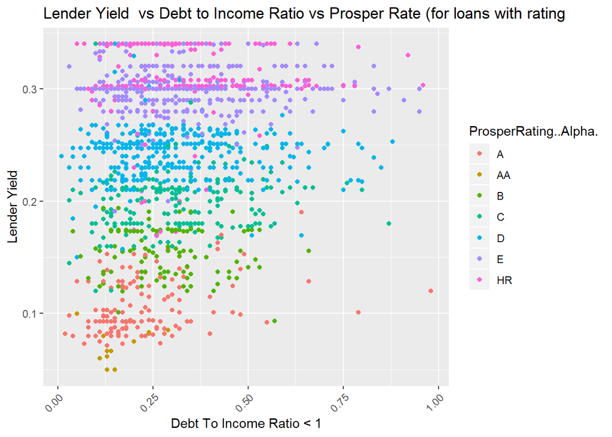

Here is how we take a closer look at Lender Yield vs Prosper Rating and how Prosper Rating was influced by Debt to Income Ratio.

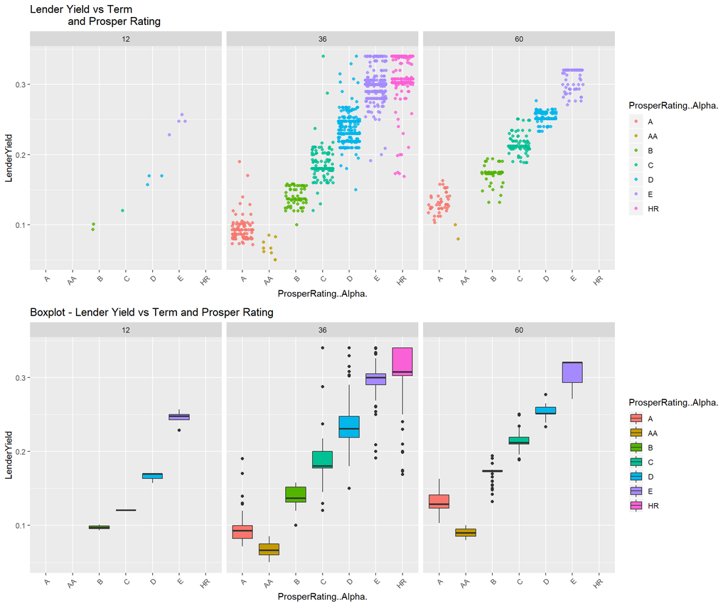

This is a closer look for lender yield vs prosper rating. The majority of loans opt-in for 36-month term and the return for 36-month and 60-month are just higher than 12-month, also considering the fact there’re less loan in 12-month term than other term.

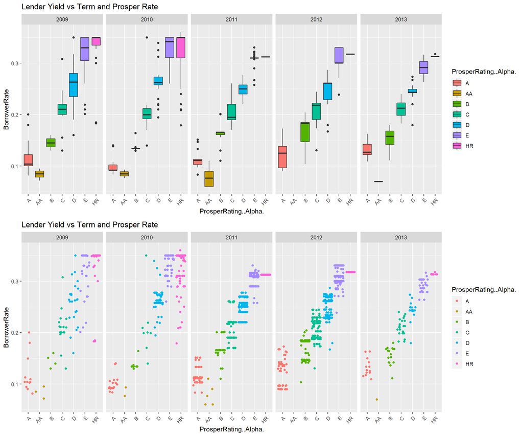

# Multivariate Analysis

### Talk about some of the relationships you observed in this part of the investigation. Were there features that strengthened each other in terms of looking at your feature(s) of interest?

Term loan is quite a good indicator whether we have a better Lender Yield or not. Also, we see how three variables Lender Yield, Prosper Rating and Debt To Income Ratio come together and how it affect each order. ### Were there any interesting or surprising interactions between features? The criteria for being an AA borrowers seems to be tighten over the year and a there seems to be a fixed borrower rate in criteria HR and AA. ### OPTIONAL: Did you create any models with your dataset? Discuss the strengths and limitations of your model. No ——

# Final Plots and Summary

### Plot One:

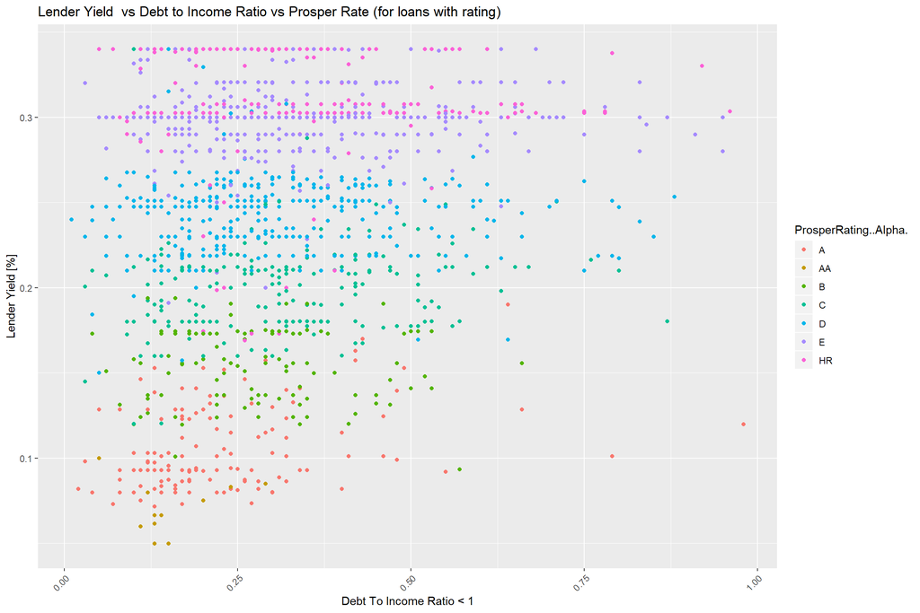

### Description One

This basically best summarize the relationship between Lender Yield and Prosper Rating. The higher the risk, the lower the rating, the better the lender yield. We also noticed high rank like AA would not have D/I ration more than 25% and although most borrowers have lower D/I Ratio, there’re still high D/I ratio borrowers and fall in lower ProsperRating. Therefore, we see a somewhat upward triangular shape.

### Plot Two

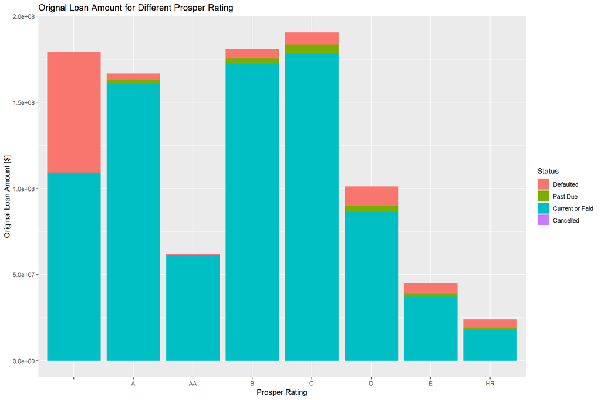

### Description Two

This chart confirmed that although there is higher lending yield for lower rating. The investors should also takes a look at the risk of the loan being defaulted. We see very clear in this chart as the rating get worsen, the higher chance the loan getting defaulted.

### Plot Three

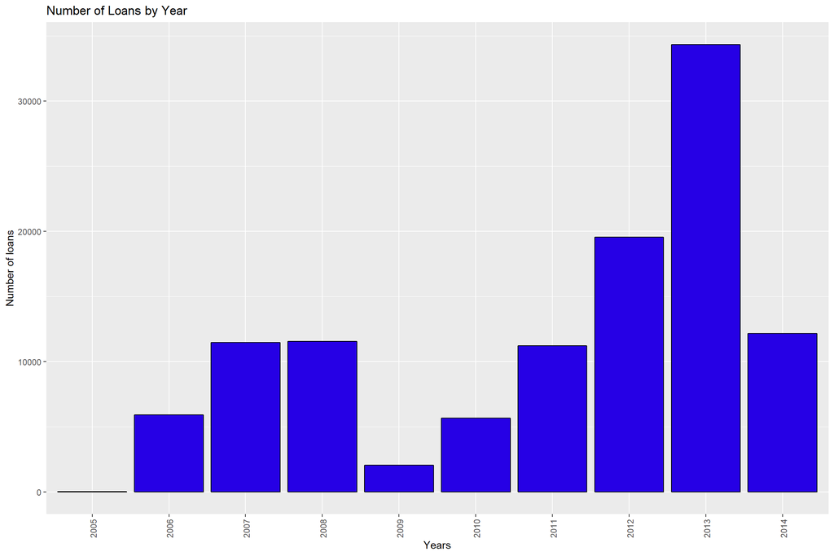

### Description Three

This graph shows a very interesting time in U.S credit business history where most of the banks and financial institution gone under strong investigation from the SEC, only to recover and went back to business and growein stronger than ever.

# Reflection

In this project I selected a dataset from Prosper.com which includes 81 variables and 113,937 observations. With so many variable it was hard to get started without any financial knowledge.

The observed default rates in the data set are quite high. Prosper provides ratings for each borrower to indicate the chance that the borrower will repay the complete loan.

Also during the analysis, the impact of the global financial crisis was clear as the data show plunge in 2009 and just start to raise in 2011, and every thin back to normal almost in 2013.